# Optimization methods for Optimal Transport

## Maksim Nekrashevich

## Kantorovich formulation of OT

$\mu$, $\nu$ - pobability measures defined on $X$, $Y$ respectively. (In general, $X$, $Y$ - continuous, but we assume them to be discrete.)

$\Pi(\mu, \nu)$ - the space of all couplings of $\mu$, $\nu$, i.e., measures $\pi$ on $X \times Y$, such that $\int_Y d\pi = d\mu$, $\int_X d\pi = d\nu$.

The relaxed OT problem is defined as follows:

$$ \operatorname{OT}(\mu, \nu) = \inf_{\pi \in \Pi(\mu,\nu)}\int\limits_{X \times Y} c(x, y)d\pi(x, y) $$

If $X$ and $Y$ are discrete, the distributions $\mu, \nu$ can be described by their probability vectors $p \in S_1(m)$ and $q \in S_1(n)$. The cost $c$ can now be represented by a matrix $C_{ij}$ as well as the measures $\pi$. So the discrete OT problem has the following form:

$$ \operatorname{OT}(p, q) = \min_{\pi \in U(p, q)}\langle C, \pi\rangle $$

[figure not shown]

## Initialize distributions

```python
def get_distribution(num_atoms: int) -> np.ndarray:
    return dirichlet(np.ones(num_atoms)).rvs().flatten()
```

```python
np.random.seed(0)

n = m = 128
p = get_distribution(n)
q = get_distribution(m)
C = np.random.rand(n, m)
```

```python
pi_true = ot.lp.emd(p, q, C)
np.sum(pi_true * C)
```

```
0.022164624400878078
```

### Primal LP problem

\begin{align*} & \langle C, \pi \rangle \to \min_{\pi} \\ \text{s.t.} \quad & \pi \geqslant 0 \\ & \pi \mathbf{1}_n = p \\ & \mathbf{1}_m^T \pi = q \end{align*}

```python
pi = cp.Variable((n, m))

primal_lp = cp.Problem(
    cp.Minimize(cp.sum(cp.multiply(C, pi))),
    [cp.sum(pi, axis=0) == q, cp.sum(pi, axis=1) == p, pi >= 0]
)
primal_lp.solve()
```

```
0.022164624396027326
```

### Dual LP problem

\begin{align*} & \langle p, f \rangle + \langle q, g \rangle \to \max_{f, g} \\ \text{s.t.} & \forall i, j \: f_i + g_j \leqslant C_{ij} \end{align*}

```python
f = cp.Variable(n)
g = cp.Variable(m)

dual_lp = cp.Problem(
    cp.Maximize(p @ f + q @ g),
    [cp.reshape(f, (n, 1)) + cp.reshape(g, (1, m)) <= C]
)

dual_lp.solve()
```

```
0.022164624395781693
```

## Entropy-regularized OT

**Motivation:** Exact solution is computationally intensive.

**Idea:** Find a *"close-enough"* solution, i.e. $\tilde{\pi}$ s.t. $\langle C,\tilde{\pi}\rangle - \langle C,\pi^*\rangle \leqslant \varepsilon$.

$$ \operatorname{OT_\gamma}(p, q) = \min_{\pi \in U(p, q)} \langle C, \pi\rangle + \gamma H(\pi) \text{, where } H(\pi) = \langle \pi,\log\pi\rangle $$

This problem is $\gamma$-strongly-convex on $S_1(n)$ in $\ell^1$-norm and therefore has a unique solution.

[figure not shown]

```python
class Sinkhorn(OTAlgorithm):
    def __init__(self, p: np.ndarray, q: np.ndarray,
                 C: np.ndarray,  gamma: float) -> None:
        super().__init__(p, q, C, gamma)
        self.u = np.zeros_like(p)
        self.v = np.zeros_like(q)
        self.B = get_B(self.C, self.gamma)

    @property
    def pi(self) -> np.ndarray:
        B = self.B(self.u, self.v)
        return B / B.sum()

    def step(self):
        self.u = -logsumexp(self.v[:, None] - self.C.T / self.gamma, b=1/self.p, axis=0)
        self.v = -logsumexp(self.u[:, None] - self.C / self.gamma, b=1/self.q, axis=0)
```

| step | cost | residual_p | residual_q |
| --- | --- | --- | --- |
| 199 | 0.025079 | 4.302628e-12 | 4.951145e-16 |

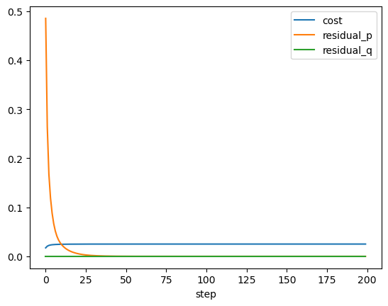

```python
sinkhorn = Sinkhorn(p, q, C, .01)
sinkhorn_history = run_algorithm(sinkhorn, 200)
sinkhorn_history.plot()
sinkhorn_history.tail(1)
```

[figure not shown]

```python
class KLProjection(OTAlgorithm):
    def __init__(self, p: np.ndarray, q: np.ndarray,
                 C: np.ndarray,  gamma: float) -> None:
        super().__init__(p, q, C, gamma)
        self.pi = np.exp(-C / gamma)

    def step(self):
        self.pi *= (self.q / self.pi.sum(0))[None]
        self.pi *= (self.p / self.pi.sum(1))[:, None]
```

| step | cost | residual_p | residual_q |
| --- | --- | --- | --- |
| 199 | 0.025079 | 1.024571e-16 | 4.581555e-12 |

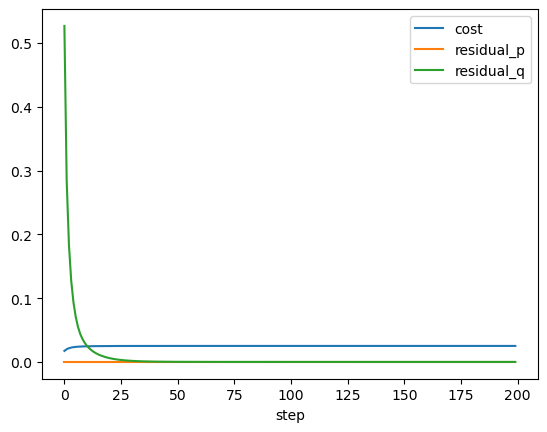

```python
kl_projection = KLProjection(p, q, C, .01)
kl_projection_history = run_algorithm(kl_projection, 200)
kl_projection_history.plot()
kl_projection_history.tail(1)
```

## Advanced algorithms

[figure not shown]

```python
class Greenkhorn(OTAlgorithm):
    def __init__(self, p: np.ndarray, q: np.ndarray, C: np.ndarray, gamma: float) -> None:
        super().__init__(p, q, C, gamma)
        self.K = np.exp(-C / gamma)
        self.u = np.ones(p.shape[0]) / p.shape[0]
        self.v = np.ones(q.shape[0]) / q.shape[0]

    @property
    def pi(self):
        return self.u[:, None] * self.K * self.v[None]

    def step(self):
        res_p = np.abs(self.pi.sum(1) - self.p)
        res_q = np.abs(self.pi.sum(0) - self.q)
        i = np.argmax(res_p)
        j = np.argmax(res_q)
        if res_p.max() > res_q.max():
            self.u[i] = self.p[i] / (self.K[i] @ self.v)
        else:
            self.v[j] = self.q[j] / (self.u @ self.K[:, j])
```

| step | cost | residual_p | residual_q |
| --- | --- | --- | --- |
| 1999 | 0.058004 | 4.226426e-07 | 4.378877e-07 |

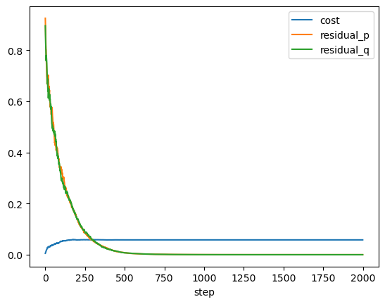

```python
greenkhorn = Greenkhorn(p, q, C, .05)
greenkhorn_history = run_algorithm(greenkhorn, 2000)
greenkhorn_history.plot()
greenkhorn_history.tail(1)
```

[figure not shown]